# Presentazione

### CPAP-Continuous Positive Airway Pressure

- **1980** --> Prof. Colin Sullivan
- AHI = (numero totale di apnee + ipopnee) / ore di sonno
- Download dati --> **OSCAR**

[figure not shown]

*(sistema CPAP con maschera nasale)*

## Domande, Ipotesi e risposte

- Domande fondamentali che mi sono posta per l'analisi del mio progetto

1. **Come posso ottenere i dati da analizzare di questo dispositivo?**
   - memory card
   - **OSCAR** (Open Source CPAP Analysis Reporter)
2. **Quali parametri sono più significativi per una corretta analisi dello strumento/paziente?**
   - AHI (*Apnea-hypopnea Index*)
   - CA (*Apnea con vie aeree libere*)
   - OA (*Apnea Ostruttiva*)
   - H (*Ipopnea*)
   - PS
   - EPAP
3. **Qual è il contributo del CPAP rispetto alla condizione iniziale del paziente?**

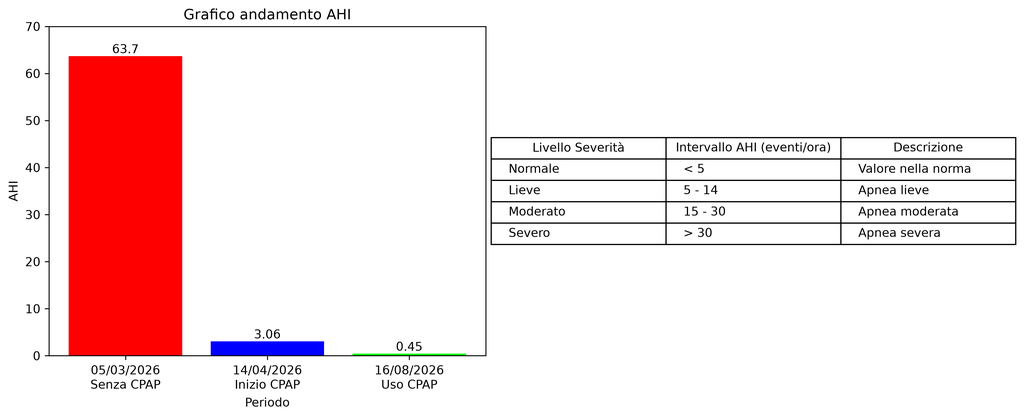

4. **In quanto tempo migliora la qualità del sonno (AHI)?**

   -Stabilizzazione dopo 2 mesi

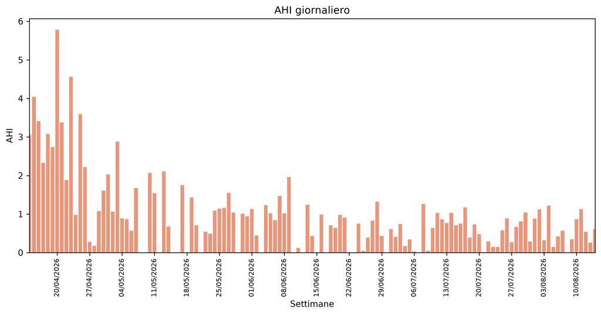

5. **Si può misurare la pressione espiratoria?**
   - Download --> query SQL --> canale 110e
   - Il valore min-Max si adatta al paziente

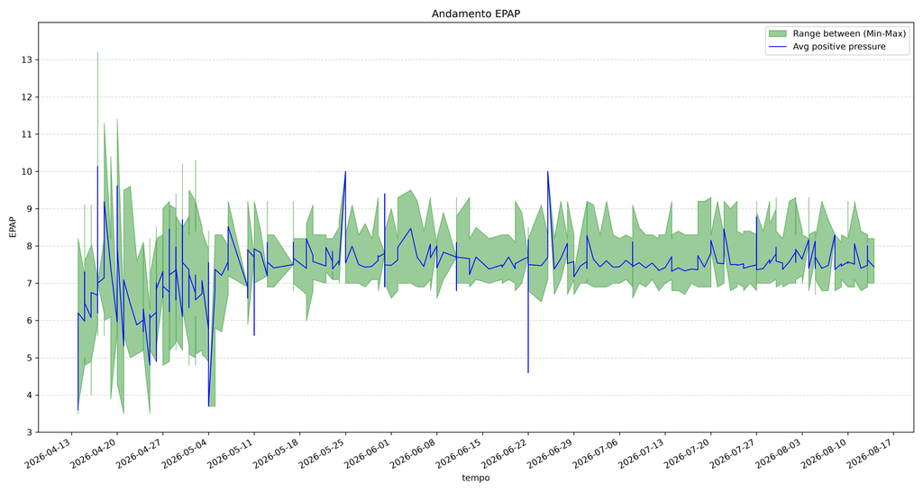

6. **È possibile notare delle correlazioni tra i parametri ottenuti?**
- **Giorni vs. AHI** --> correlazione negativa moderatamente forte.  
  ✅ Conferma: l'uso costante contrasta apnee

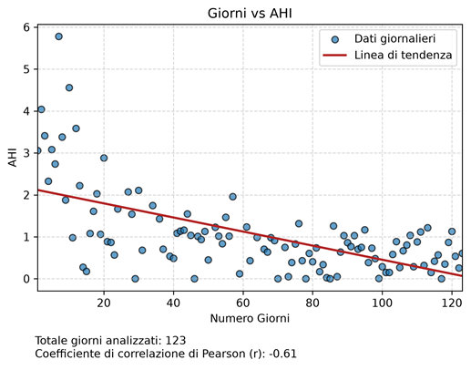

- **Ore vs. AHI** --> 2 variabili indipendenti.  
  ❌ Nessuna relazione: la durata del sonno non predice un AHI alto o basso

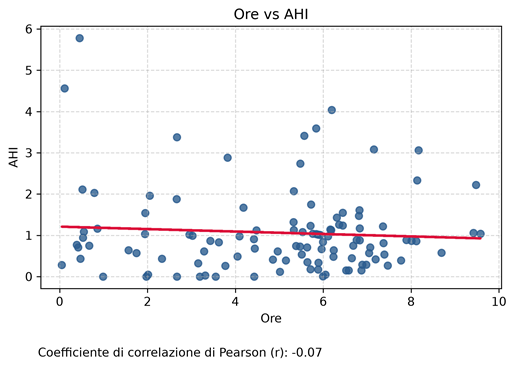

- **OA_H_CA vs. AHI** --> correlazione positiva proporzionale AHI.  
  🔗 Correlate: AHI valore medio di tutte le apnee

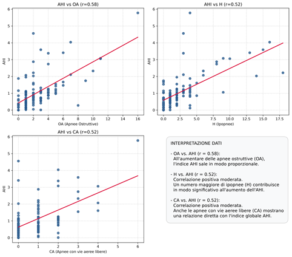

7. **Ci sono aspetti negativi?**
   - Costanza d'uso
   - Manutenzione

❗ATTENZIONE: il CPAP è un rimedio, non una cura.

## Conclusione

✨ **Efficacia**: L'analisi conferma l'impatto positivo dello strumento sul paziente.